# Risk Factor Analysis

## Outcome Variable

**Outcome Variable:** ever_wasted

## Predictor Variables

**Intervention Variable:** exclfeed3

**Adjustment Set:**

unadjusted

## Stratifying Variables

The analysis was stratified on these variable(s):

- agecat
- studyid
- country

## Data Summary

| agecat | studyid | country | exclfeed3 | ever_wasted | n_cell | n |
| --- | --- | --- | --- | --- | --- | --- |
| 0-24 months (no birth wast) | CMC-V-BCS-2002 | INDIA | 1 | 0 | 4 | 10 |
| 0-24 months (no birth wast) | CMC-V-BCS-2002 | INDIA | 1 | 1 | 6 | 10 |
| 0-24 months (no birth wast) | CMC-V-BCS-2002 | INDIA | 0 | 0 | 0 | 10 |
| 0-24 months (no birth wast) | CMC-V-BCS-2002 | INDIA | 0 | 1 | 0 | 10 |
| 0-24 months (no birth wast) | EE | PAKISTAN | 1 | 0 | 18 | 39 |
| 0-24 months (no birth wast) | EE | PAKISTAN | 1 | 1 | 21 | 39 |
| 0-24 months (no birth wast) | EE | PAKISTAN | 0 | 0 | 0 | 39 |
| 0-24 months (no birth wast) | EE | PAKISTAN | 0 | 1 | 0 | 39 |
| 0-24 months (no birth wast) | GMS-Nepal | NEPAL | 1 | 0 | 147 | 453 |
| 0-24 months (no birth wast) | GMS-Nepal | NEPAL | 1 | 1 | 229 | 453 |
| 0-24 months (no birth wast) | GMS-Nepal | NEPAL | 0 | 0 | 39 | 453 |
| 0-24 months (no birth wast) | GMS-Nepal | NEPAL | 0 | 1 | 38 | 453 |
| 0-24 months (no birth wast) | IRC | INDIA | 1 | 0 | 0 | 10 |
| 0-24 months (no birth wast) | IRC | INDIA | 1 | 1 | 0 | 10 |
| 0-24 months (no birth wast) | IRC | INDIA | 0 | 0 | 4 | 10 |
| 0-24 months (no birth wast) | IRC | INDIA | 0 | 1 | 6 | 10 |
| 0-24 months (no birth wast) | JiVitA-3 | BANGLADESH | 1 | 0 | 11034 | 14768 |
| 0-24 months (no birth wast) | JiVitA-3 | BANGLADESH | 1 | 1 | 2327 | 14768 |
| 0-24 months (no birth wast) | JiVitA-3 | BANGLADESH | 0 | 0 | 1167 | 14768 |
| 0-24 months (no birth wast) | JiVitA-3 | BANGLADESH | 0 | 1 | 240 | 14768 |
| 0-24 months (no birth wast) | JiVitA-4 | BANGLADESH | 1 | 0 | 109 | 164 |
| 0-24 months (no birth wast) | JiVitA-4 | BANGLADESH | 1 | 1 | 38 | 164 |
| 0-24 months (no birth wast) | JiVitA-4 | BANGLADESH | 0 | 0 | 13 | 164 |
| 0-24 months (no birth wast) | JiVitA-4 | BANGLADESH | 0 | 1 | 4 | 164 |
| 0-24 months (no birth wast) | Keneba | GAMBIA | 1 | 0 | 1100 | 2015 |
| 0-24 months (no birth wast) | Keneba | GAMBIA | 1 | 1 | 695 | 2015 |
| 0-24 months (no birth wast) | Keneba | GAMBIA | 0 | 0 | 120 | 2015 |
| 0-24 months (no birth wast) | Keneba | GAMBIA | 0 | 1 | 100 | 2015 |
| 0-24 months (no birth wast) | MAL-ED | BANGLADESH | 1 | 0 | 123 | 244 |
| 0-24 months (no birth wast) | MAL-ED | BANGLADESH | 1 | 1 | 36 | 244 |

[output cut: 162 more lines]

The following strata were considered:

- agecat: 0-24 months (no birth wast), studyid: CMC-V-BCS-2002, country: INDIA
- agecat: 0-24 months (no birth wast), studyid: EE, country: PAKISTAN
- agecat: 0-24 months (no birth wast), studyid: GMS-Nepal, country: NEPAL
- agecat: 0-24 months (no birth wast), studyid: IRC, country: INDIA
- agecat: 0-24 months (no birth wast), studyid: JiVitA-3, country: BANGLADESH
- agecat: 0-24 months (no birth wast), studyid: JiVitA-4, country: BANGLADESH
- agecat: 0-24 months (no birth wast), studyid: Keneba, country: GAMBIA
- agecat: 0-24 months (no birth wast), studyid: MAL-ED, country: BANGLADESH
- agecat: 0-24 months (no birth wast), studyid: MAL-ED, country: BRAZIL
- agecat: 0-24 months (no birth wast), studyid: MAL-ED, country: INDIA
- agecat: 0-24 months (no birth wast), studyid: MAL-ED, country: NEPAL
- agecat: 0-24 months (no birth wast), studyid: MAL-ED, country: PERU
- agecat: 0-24 months (no birth wast), studyid: MAL-ED, country: SOUTH AFRICA
- agecat: 0-24 months (no birth wast), studyid: MAL-ED, country: TANZANIA, UNITED REPUBLIC OF
- agecat: 0-24 months (no birth wast), studyid: PROVIDE, country: BANGLADESH
- agecat: 0-24 months (no birth wast), studyid: SAS-CompFeed, country: INDIA
- agecat: 0-6 months (no birth wast), studyid: CMC-V-BCS-2002, country: INDIA
- agecat: 0-6 months (no birth wast), studyid: EE, country: PAKISTAN
- agecat: 0-6 months (no birth wast), studyid: GMS-Nepal, country: NEPAL
- agecat: 0-6 months (no birth wast), studyid: IRC, country: INDIA
- agecat: 0-6 months (no birth wast), studyid: JiVitA-3, country: BANGLADESH
- agecat: 0-6 months (no birth wast), studyid: JiVitA-4, country: BANGLADESH
- agecat: 0-6 months (no birth wast), studyid: Keneba, country: GAMBIA
- agecat: 0-6 months (no birth wast), studyid: MAL-ED, country: BANGLADESH
- agecat: 0-6 months (no birth wast), studyid: MAL-ED, country: BRAZIL
- agecat: 0-6 months (no birth wast), studyid: MAL-ED, country: INDIA
- agecat: 0-6 months (no birth wast), studyid: MAL-ED, country: NEPAL
- agecat: 0-6 months (no birth wast), studyid: MAL-ED, country: PERU
- agecat: 0-6 months (no birth wast), studyid: MAL-ED, country: SOUTH AFRICA
- agecat: 0-6 months (no birth wast), studyid: MAL-ED, country: TANZANIA, UNITED REPUBLIC OF
- agecat: 0-6 months (no birth wast), studyid: PROVIDE, country: BANGLADESH
- agecat: 0-6 months (no birth wast), studyid: SAS-CompFeed, country: INDIA
- agecat: 6-24 months, studyid: CMC-V-BCS-2002, country: INDIA
- agecat: 6-24 months, studyid: EE, country: PAKISTAN
- agecat: 6-24 months, studyid: GMS-Nepal, country: NEPAL
- agecat: 6-24 months, studyid: IRC, country: INDIA
- agecat: 6-24 months, studyid: JiVitA-3, country: BANGLADESH
- agecat: 6-24 months, studyid: JiVitA-4, country: BANGLADESH
- agecat: 6-24 months, studyid: Keneba, country: GAMBIA
- agecat: 6-24 months, studyid: MAL-ED, country: BANGLADESH
- agecat: 6-24 months, studyid: MAL-ED, country: BRAZIL
- agecat: 6-24 months, studyid: MAL-ED, country: INDIA
- agecat: 6-24 months, studyid: MAL-ED, country: NEPAL
- agecat: 6-24 months, studyid: MAL-ED, country: PERU
- agecat: 6-24 months, studyid: MAL-ED, country: SOUTH AFRICA
- agecat: 6-24 months, studyid: MAL-ED, country: TANZANIA, UNITED REPUBLIC OF
- agecat: 6-24 months, studyid: PROVIDE, country: BANGLADESH
- agecat: 6-24 months, studyid: SAS-CompFeed, country: INDIA

### Dropped Strata

Some strata were dropped due to rare outcomes:

- agecat: 0-24 months (no birth wast), studyid: CMC-V-BCS-2002, country: INDIA
- agecat: 0-24 months (no birth wast), studyid: EE, country: PAKISTAN
- agecat: 0-24 months (no birth wast), studyid: IRC, country: INDIA
- agecat: 0-24 months (no birth wast), studyid: JiVitA-4, country: BANGLADESH
- agecat: 0-24 months (no birth wast), studyid: MAL-ED, country: PERU
- agecat: 0-24 months (no birth wast), studyid: MAL-ED, country: SOUTH AFRICA
- agecat: 0-6 months (no birth wast), studyid: CMC-V-BCS-2002, country: INDIA
- agecat: 0-6 months (no birth wast), studyid: EE, country: PAKISTAN
- agecat: 0-6 months (no birth wast), studyid: IRC, country: INDIA
- agecat: 0-6 months (no birth wast), studyid: JiVitA-4, country: BANGLADESH
- agecat: 0-6 months (no birth wast), studyid: MAL-ED, country: BRAZIL
- agecat: 0-6 months (no birth wast), studyid: MAL-ED, country: NEPAL
- agecat: 0-6 months (no birth wast), studyid: MAL-ED, country: PERU
- agecat: 0-6 months (no birth wast), studyid: MAL-ED, country: SOUTH AFRICA
- agecat: 0-6 months (no birth wast), studyid: MAL-ED, country: TANZANIA, UNITED REPUBLIC OF
- agecat: 6-24 months, studyid: CMC-V-BCS-2002, country: INDIA
- agecat: 6-24 months, studyid: EE, country: PAKISTAN
- agecat: 6-24 months, studyid: IRC, country: INDIA
- agecat: 6-24 months, studyid: JiVitA-4, country: BANGLADESH
- agecat: 6-24 months, studyid: MAL-ED, country: BRAZIL
- agecat: 6-24 months, studyid: MAL-ED, country: PERU
- agecat: 6-24 months, studyid: MAL-ED, country: SOUTH AFRICA
- agecat: 6-24 months, studyid: MAL-ED, country: TANZANIA, UNITED REPUBLIC OF

## Methods Detail

We’re interested in the causal parameters $E[Y_a]$ for all values of $a \in \mathcal{A}$. These parameters represent the mean outcome if, possibly contrary to fact, we intervened to set all units to have $A=a$. Under the randomization and positivity assumptions, these are identified by the statistical parameters $\psi_a=E_W[E_{Y|A,W}(Y|A=a,W)]$. In addition, we’re interested in the mean of $Y$, $E[Y]$ under no intervention (the observed mean). We will estimate these parameters by using SuperLearner to fit the relevant likelihood factors – $E_{Y|A,W}(Y|A=a,W)$ and $p(A=a|W)$, and then updating our likelihood fit using a joint TMLE.

For unadjusted analyses ($W=\{\}$), initial likelihoods were estimated using Lrnr_glm to estimate the simple $E(Y|A)$ and Lrnr_mean to estimate $p(A)$. For adjusted analyses, a small library containing Lrnr_glmnet, Lrnr_xgboost, and Lrnr_mean was used.

Having estimated these parameters, we will then use the delta method to estimate relative risks and attributable risks relative to a prespecified baseline level of $A$.

# Results Detail

## Results Plots

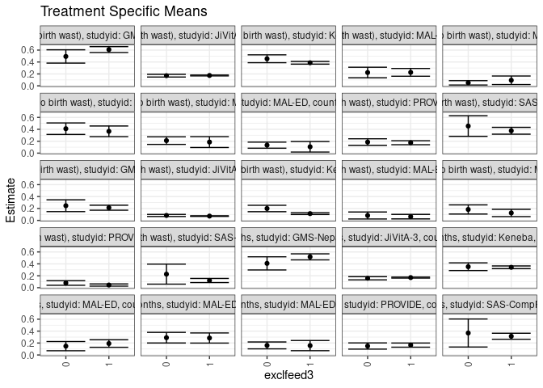

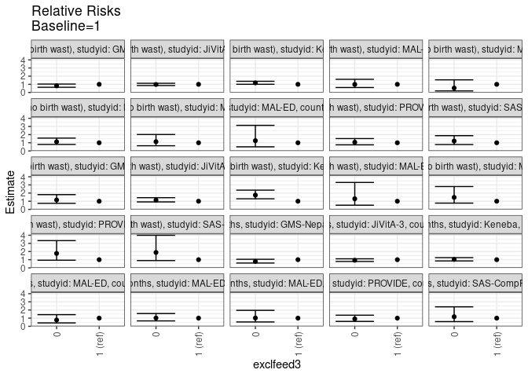

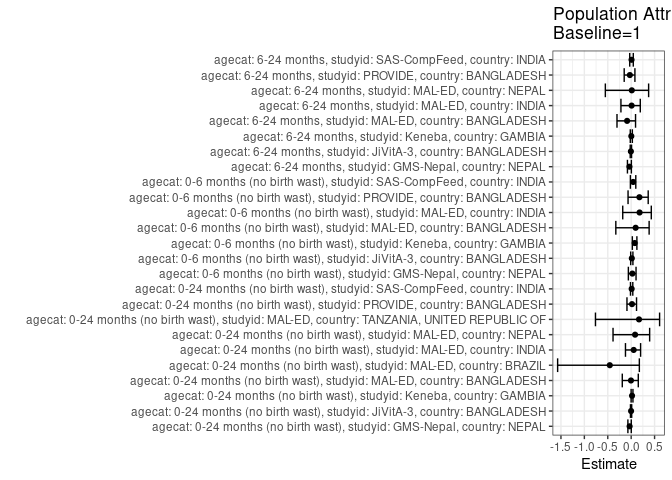

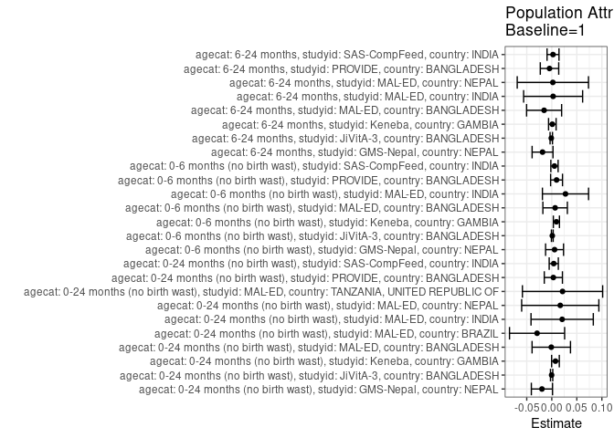

## Results Table

### Parameter: TSM

| agecat | studyid | country | intervention_level | baseline_level | estimate | ci_lower | ci_upper |
| --- | --- | --- | --- | --- | --- | --- | --- |
| 0-24 months (no birth wast) | GMS-Nepal | NEPAL | 1 | NA | 0.6090426 | 0.5596658 | 0.6584193 |
| 0-24 months (no birth wast) | GMS-Nepal | NEPAL | 0 | NA | 0.4935065 | 0.3817131 | 0.6052998 |
| 0-24 months (no birth wast) | JiVitA-3 | BANGLADESH | 1 | NA | 0.1741636 | 0.1671520 | 0.1811752 |
| 0-24 months (no birth wast) | JiVitA-3 | BANGLADESH | 0 | NA | 0.1705757 | 0.1475979 | 0.1935535 |
| 0-24 months (no birth wast) | Keneba | GAMBIA | 1 | NA | 0.3871866 | 0.3646469 | 0.4097263 |
| 0-24 months (no birth wast) | Keneba | GAMBIA | 0 | NA | 0.4545455 | 0.3887323 | 0.5203586 |
| 0-24 months (no birth wast) | MAL-ED | BANGLADESH | 1 | NA | 0.2264151 | 0.1612300 | 0.2916001 |
| 0-24 months (no birth wast) | MAL-ED | BANGLADESH | 0 | NA | 0.2235294 | 0.1347811 | 0.3122778 |
| 0-24 months (no birth wast) | MAL-ED | BRAZIL | 1 | NA | 0.0937500 | 0.0221611 | 0.1653389 |
| 0-24 months (no birth wast) | MAL-ED | BRAZIL | 0 | NA | 0.0507246 | 0.0140225 | 0.0874268 |
| 0-24 months (no birth wast) | MAL-ED | INDIA | 1 | NA | 0.3660714 | 0.2766444 | 0.4554985 |
| 0-24 months (no birth wast) | MAL-ED | INDIA | 0 | NA | 0.4100000 | 0.3133743 | 0.5066257 |
| 0-24 months (no birth wast) | MAL-ED | NEPAL | 1 | NA | 0.1857143 | 0.0944147 | 0.2770139 |
| 0-24 months (no birth wast) | MAL-ED | NEPAL | 0 | NA | 0.2101911 | 0.1463169 | 0.2740652 |
| 0-24 months (no birth wast) | MAL-ED | TANZANIA, UNITED REPUBLIC OF | 1 | NA | 0.1063830 | 0.0180333 | 0.1947326 |
| 0-24 months (no birth wast) | MAL-ED | TANZANIA, UNITED REPUBLIC OF | 0 | NA | 0.1337209 | 0.0827402 | 0.1847017 |
| 0-24 months (no birth wast) | PROVIDE | BANGLADESH | 1 | NA | 0.1744422 | 0.1409194 | 0.2079650 |
| 0-24 months (no birth wast) | PROVIDE | BANGLADESH | 0 | NA | 0.1855670 | 0.1308224 | 0.2403116 |
| 0-24 months (no birth wast) | SAS-CompFeed | INDIA | 1 | NA | 0.3752969 | 0.3178349 | 0.4327589 |
| 0-24 months (no birth wast) | SAS-CompFeed | INDIA | 0 | NA | 0.4545455 | 0.2817186 | 0.6273723 |
| 0-6 months (no birth wast) | GMS-Nepal | NEPAL | 1 | NA | 0.2131148 | 0.1711132 | 0.2551163 |
| 0-6 months (no birth wast) | GMS-Nepal | NEPAL | 0 | NA | 0.2465753 | 0.1475887 | 0.3455620 |
| 0-6 months (no birth wast) | JiVitA-3 | BANGLADESH | 1 | NA | 0.0725393 | 0.0674134 | 0.0776651 |
| 0-6 months (no birth wast) | JiVitA-3 | BANGLADESH | 0 | NA | 0.0831541 | 0.0654419 | 0.1008663 |
| 0-6 months (no birth wast) | Keneba | GAMBIA | 1 | NA | 0.1142217 | 0.0994663 | 0.1289772 |
| 0-6 months (no birth wast) | Keneba | GAMBIA | 0 | NA | 0.2000000 | 0.1465193 | 0.2534807 |
| 0-6 months (no birth wast) | MAL-ED | BANGLADESH | 1 | NA | 0.0632911 | 0.0252469 | 0.1013354 |
| 0-6 months (no birth wast) | MAL-ED | BANGLADESH | 0 | NA | 0.0823529 | 0.0237915 | 0.1409143 |
| 0-6 months (no birth wast) | MAL-ED | INDIA | 1 | NA | 0.1250000 | 0.0636048 | 0.1863952 |
| 0-6 months (no birth wast) | MAL-ED | INDIA | 0 | NA | 0.1836735 | 0.1068265 | 0.2605204 |
| 0-6 months (no birth wast) | PROVIDE | BANGLADESH | 1 | NA | 0.0446247 | 0.0263850 | 0.0628644 |
| 0-6 months (no birth wast) | PROVIDE | BANGLADESH | 0 | NA | 0.0789474 | 0.0405766 | 0.1173181 |
| 0-6 months (no birth wast) | SAS-CompFeed | INDIA | 1 | NA | 0.1204819 | 0.0857775 | 0.1551864 |
| 0-6 months (no birth wast) | SAS-CompFeed | INDIA | 0 | NA | 0.2272727 | 0.0595457 | 0.3949997 |
| 6-24 months | GMS-Nepal | NEPAL | 1 | NA | 0.5173333 | 0.4667015 | 0.5679651 |
| 6-24 months | GMS-Nepal | NEPAL | 0 | NA | 0.4078947 | 0.2972841 | 0.5185054 |
| 6-24 months | JiVitA-3 | BANGLADESH | 1 | NA | 0.1694356 | 0.1611276 | 0.1777436 |
| 6-24 months | JiVitA-3 | BANGLADESH | 0 | NA | 0.1578313 | 0.1309176 | 0.1847450 |
| 6-24 months | Keneba | GAMBIA | 1 | NA | 0.3423529 | 0.3197913 | 0.3649146 |
| 6-24 months | Keneba | GAMBIA | 0 | NA | 0.3523810 | 0.2877533 | 0.4170086 |
| 6-24 months | MAL-ED | BANGLADESH | 1 | NA | 0.1920530 | 0.1290879 | 0.2550180 |
| 6-24 months | MAL-ED | BANGLADESH | 0 | NA | 0.1481481 | 0.0706174 | 0.2256789 |
| 6-24 months | MAL-ED | INDIA | 1 | NA | 0.2844037 | 0.1995095 | 0.3692979 |
| 6-24 months | MAL-ED | INDIA | 0 | NA | 0.2900000 | 0.2008507 | 0.3791493 |
| 6-24 months | MAL-ED | NEPAL | 1 | NA | 0.1571429 | 0.0716979 | 0.2425878 |
| 6-24 months | MAL-ED | NEPAL | 0 | NA | 0.1602564 | 0.1025625 | 0.2179503 |
| 6-24 months | PROVIDE | BANGLADESH | 1 | NA | 0.1655172 | 0.1305640 | 0.2004705 |
| 6-24 months | PROVIDE | BANGLADESH | 0 | NA | 0.1500000 | 0.0977940 | 0.2022060 |
| 6-24 months | SAS-CompFeed | INDIA | 1 | NA | 0.3140704 | 0.2638452 | 0.3642955 |
| 6-24 months | SAS-CompFeed | INDIA | 0 | NA | 0.3684211 | 0.1333387 | 0.6035034 |

### Parameter: E(Y)

| agecat | studyid | country | intervention_level | baseline_level | estimate | ci_lower | ci_upper |
| --- | --- | --- | --- | --- | --- | --- | --- |
| 0-24 months (no birth wast) | GMS-Nepal | NEPAL | NA | NA | 0.5894040 | 0.5440524 | 0.6347556 |
| 0-24 months (no birth wast) | JiVitA-3 | BANGLADESH | NA | NA | 0.1738218 | 0.1671074 | 0.1805361 |
| 0-24 months (no birth wast) | Keneba | GAMBIA | NA | NA | 0.3945409 | 0.3731954 | 0.4158865 |
| 0-24 months (no birth wast) | MAL-ED | BANGLADESH | NA | NA | 0.2254098 | 0.1728726 | 0.2779471 |
| 0-24 months (no birth wast) | MAL-ED | BRAZIL | NA | NA | 0.0643564 | 0.0304329 | 0.0982800 |
| 0-24 months (no birth wast) | MAL-ED | INDIA | NA | NA | 0.3867925 | 0.3210797 | 0.4525052 |
| 0-24 months (no birth wast) | MAL-ED | NEPAL | NA | NA | 0.2026432 | 0.1502365 | 0.2550498 |
| 0-24 months (no birth wast) | MAL-ED | TANZANIA, UNITED REPUBLIC OF | NA | NA | 0.1278539 | 0.0835266 | 0.1721812 |
| 0-24 months (no birth wast) | PROVIDE | BANGLADESH | NA | NA | 0.1775837 | 0.1489858 | 0.2061816 |
| 0-24 months (no birth wast) | SAS-CompFeed | INDIA | NA | NA | 0.3792325 | 0.3255512 | 0.4329138 |
| 0-6 months (no birth wast) | GMS-Nepal | NEPAL | NA | NA | 0.2186788 | 0.1799683 | 0.2573894 |
| 0-6 months (no birth wast) | JiVitA-3 | BANGLADESH | NA | NA | 0.0735505 | 0.0685774 | 0.0785236 |
| 0-6 months (no birth wast) | Keneba | GAMBIA | NA | NA | 0.1234383 | 0.1090221 | 0.1378544 |
| 0-6 months (no birth wast) | MAL-ED | BANGLADESH | NA | NA | 0.0699588 | 0.0378213 | 0.1020964 |
| 0-6 months (no birth wast) | MAL-ED | INDIA | NA | NA | 0.1523810 | 0.1036572 | 0.2011047 |
| 0-6 months (no birth wast) | PROVIDE | BANGLADESH | NA | NA | 0.0541728 | 0.0371844 | 0.0711612 |
| 0-6 months (no birth wast) | SAS-CompFeed | INDIA | NA | NA | 0.1258581 | 0.0910745 | 0.1606418 |
| 6-24 months | GMS-Nepal | NEPAL | NA | NA | 0.4988914 | 0.4526947 | 0.5450880 |
| 6-24 months | JiVitA-3 | BANGLADESH | NA | NA | 0.1684342 | 0.1604630 | 0.1764054 |
| 6-24 months | Keneba | GAMBIA | NA | NA | 0.3434555 | 0.3221539 | 0.3647571 |
| 6-24 months | MAL-ED | BANGLADESH | NA | NA | 0.1767241 | 0.1275357 | 0.2259125 |
| 6-24 months | MAL-ED | INDIA | NA | NA | 0.2870813 | 0.2256006 | 0.3485621 |
| 6-24 months | MAL-ED | NEPAL | NA | NA | 0.1592920 | 0.1114757 | 0.2071084 |
| 6-24 months | PROVIDE | BANGLADESH | NA | NA | 0.1609756 | 0.1319065 | 0.1900447 |
| 6-24 months | SAS-CompFeed | INDIA | NA | NA | 0.3165468 | 0.2711185 | 0.3619751 |

### Parameter: RR

| agecat | studyid | country | intervention_level | baseline_level | estimate | ci_lower | ci_upper |
| --- | --- | --- | --- | --- | --- | --- | --- |
| 0-24 months (no birth wast) | GMS-Nepal | NEPAL | 1 | 1 | 1.0000000 | 1.0000000 | 1.000000 |
| 0-24 months (no birth wast) | GMS-Nepal | NEPAL | 0 | 1 | 0.8102989 | 0.6370218 | 1.030709 |
| 0-24 months (no birth wast) | JiVitA-3 | BANGLADESH | 1 | 1 | 1.0000000 | 1.0000000 | 1.000000 |
| 0-24 months (no birth wast) | JiVitA-3 | BANGLADESH | 0 | 1 | 0.9793992 | 0.8510015 | 1.127169 |
| 0-24 months (no birth wast) | Keneba | GAMBIA | 1 | 1 | 1.0000000 | 1.0000000 | 1.000000 |
| 0-24 months (no birth wast) | Keneba | GAMBIA | 0 | 1 | 1.1739699 | 1.0043470 | 1.372240 |
| 0-24 months (no birth wast) | MAL-ED | BANGLADESH | 1 | 1 | 1.0000000 | 1.0000000 | 1.000000 |
| 0-24 months (no birth wast) | MAL-ED | BANGLADESH | 0 | 1 | 0.9872549 | 0.6045586 | 1.612205 |
| 0-24 months (no birth wast) | MAL-ED | BRAZIL | 1 | 1 | 1.0000000 | 1.0000000 | 1.000000 |
| 0-24 months (no birth wast) | MAL-ED | BRAZIL | 0 | 1 | 0.5410628 | 0.1889656 | 1.549219 |
| 0-24 months (no birth wast) | MAL-ED | INDIA | 1 | 1 | 1.0000000 | 1.0000000 | 1.000000 |
| 0-24 months (no birth wast) | MAL-ED | INDIA | 0 | 1 | 1.1200000 | 0.7976306 | 1.572658 |
| 0-24 months (no birth wast) | MAL-ED | NEPAL | 1 | 1 | 1.0000000 | 1.0000000 | 1.000000 |
| 0-24 months (no birth wast) | MAL-ED | NEPAL | 0 | 1 | 1.1317981 | 0.6349901 | 2.017302 |
| 0-24 months (no birth wast) | MAL-ED | TANZANIA, UNITED REPUBLIC OF | 1 | 1 | 1.0000000 | 1.0000000 | 1.000000 |
| 0-24 months (no birth wast) | MAL-ED | TANZANIA, UNITED REPUBLIC OF | 0 | 1 | 1.2569767 | 0.5040371 | 3.134671 |
| 0-24 months (no birth wast) | PROVIDE | BANGLADESH | 1 | 1 | 1.0000000 | 1.0000000 | 1.000000 |
| 0-24 months (no birth wast) | PROVIDE | BANGLADESH | 0 | 1 | 1.0637737 | 0.7480688 | 1.512714 |
| 0-24 months (no birth wast) | SAS-CompFeed | INDIA | 1 | 1 | 1.0000000 | 1.0000000 | 1.000000 |
| 0-24 months (no birth wast) | SAS-CompFeed | INDIA | 0 | 1 | 1.2111623 | 0.7836492 | 1.871902 |
| 0-6 months (no birth wast) | GMS-Nepal | NEPAL | 1 | 1 | 1.0000000 | 1.0000000 | 1.000000 |
| 0-6 months (no birth wast) | GMS-Nepal | NEPAL | 0 | 1 | 1.1570074 | 0.7397982 | 1.809502 |
| 0-6 months (no birth wast) | JiVitA-3 | BANGLADESH | 1 | 1 | 1.0000000 | 1.0000000 | 1.000000 |
| 0-6 months (no birth wast) | JiVitA-3 | BANGLADESH | 0 | 1 | 1.1463328 | 0.9173862 | 1.432416 |
| 0-6 months (no birth wast) | Keneba | GAMBIA | 1 | 1 | 1.0000000 | 1.0000000 | 1.000000 |
| 0-6 months (no birth wast) | Keneba | GAMBIA | 0 | 1 | 1.7509804 | 1.3010908 | 2.356432 |
| 0-6 months (no birth wast) | MAL-ED | BANGLADESH | 1 | 1 | 1.0000000 | 1.0000000 | 1.000000 |
| 0-6 months (no birth wast) | MAL-ED | BANGLADESH | 0 | 1 | 1.3011765 | 0.5128087 | 3.301544 |
| 0-6 months (no birth wast) | MAL-ED | INDIA | 1 | 1 | 1.0000000 | 1.0000000 | 1.000000 |
| 0-6 months (no birth wast) | MAL-ED | INDIA | 0 | 1 | 1.4693878 | 0.7707748 | 2.801208 |
| 0-6 months (no birth wast) | PROVIDE | BANGLADESH | 1 | 1 | 1.0000000 | 1.0000000 | 1.000000 |
| 0-6 months (no birth wast) | PROVIDE | BANGLADESH | 0 | 1 | 1.7691388 | 0.9374820 | 3.338573 |
| 0-6 months (no birth wast) | SAS-CompFeed | INDIA | 1 | 1 | 1.0000000 | 1.0000000 | 1.000000 |
| 0-6 months (no birth wast) | SAS-CompFeed | INDIA | 0 | 1 | 1.8863636 | 0.8915751 | 3.991103 |
| 6-24 months | GMS-Nepal | NEPAL | 1 | 1 | 1.0000000 | 1.0000000 | 1.000000 |
| 6-24 months | GMS-Nepal | NEPAL | 0 | 1 | 0.7884563 | 0.5909797 | 1.051920 |
| 6-24 months | JiVitA-3 | BANGLADESH | 1 | 1 | 1.0000000 | 1.0000000 | 1.000000 |
| 6-24 months | JiVitA-3 | BANGLADESH | 0 | 1 | 0.9315122 | 0.7805863 | 1.111619 |
| 6-24 months | Keneba | GAMBIA | 1 | 1 | 1.0000000 | 1.0000000 | 1.000000 |
| 6-24 months | Keneba | GAMBIA | 0 | 1 | 1.0292914 | 0.8470353 | 1.250763 |
| 6-24 months | MAL-ED | BANGLADESH | 1 | 1 | 1.0000000 | 1.0000000 | 1.000000 |
| 6-24 months | MAL-ED | BANGLADESH | 0 | 1 | 0.7713921 | 0.4159854 | 1.430449 |
| 6-24 months | MAL-ED | INDIA | 1 | 1 | 1.0000000 | 1.0000000 | 1.000000 |
| 6-24 months | MAL-ED | INDIA | 0 | 1 | 1.0196774 | 0.6643121 | 1.565141 |
| 6-24 months | MAL-ED | NEPAL | 1 | 1 | 1.0000000 | 1.0000000 | 1.000000 |
| 6-24 months | MAL-ED | NEPAL | 0 | 1 | 1.0198135 | 0.5312617 | 1.957641 |
| 6-24 months | PROVIDE | BANGLADESH | 1 | 1 | 1.0000000 | 1.0000000 | 1.000000 |
| 6-24 months | PROVIDE | BANGLADESH | 0 | 1 | 0.9062500 | 0.6031823 | 1.361593 |
| 6-24 months | SAS-CompFeed | INDIA | 1 | 1 | 1.0000000 | 1.0000000 | 1.000000 |
| 6-24 months | SAS-CompFeed | INDIA | 0 | 1 | 1.1730526 | 0.5767231 | 2.385985 |

### Parameter: PAR

| agecat | studyid | country | intervention_level | baseline_level | estimate | ci_lower | ci_upper |
| --- | --- | --- | --- | --- | --- | --- | --- |
| 0-24 months (no birth wast) | GMS-Nepal | NEPAL | 1 | NA | -0.0196386 | -0.0407937 | 0.0015165 |
| 0-24 months (no birth wast) | JiVitA-3 | BANGLADESH | 1 | NA | -0.0003418 | -0.0026291 | 0.0019454 |
| 0-24 months (no birth wast) | Keneba | GAMBIA | 1 | NA | 0.0073543 | -0.0002962 | 0.0150048 |
| 0-24 months (no birth wast) | MAL-ED | BANGLADESH | 1 | NA | -0.0010053 | -0.0393655 | 0.0373549 |
| 0-24 months (no birth wast) | MAL-ED | BRAZIL | 1 | NA | -0.0293936 | -0.0844233 | 0.0256361 |
| 0-24 months (no birth wast) | MAL-ED | INDIA | 1 | NA | 0.0207210 | -0.0414521 | 0.0828941 |
| 0-24 months (no birth wast) | MAL-ED | NEPAL | 1 | NA | 0.0169289 | -0.0601500 | 0.0940078 |
| 0-24 months (no birth wast) | MAL-ED | TANZANIA, UNITED REPUBLIC OF | 1 | NA | 0.0214709 | -0.0586552 | 0.1015970 |
| 0-24 months (no birth wast) | PROVIDE | BANGLADESH | 1 | NA | 0.0031415 | -0.0149897 | 0.0212727 |
| 0-24 months (no birth wast) | SAS-CompFeed | INDIA | 1 | NA | 0.0039356 | -0.0052013 | 0.0130725 |
| 0-6 months (no birth wast) | GMS-Nepal | NEPAL | 1 | NA | 0.0055641 | -0.0123546 | 0.0234828 |
| 0-6 months (no birth wast) | JiVitA-3 | BANGLADESH | 1 | NA | 0.0010113 | -0.0007386 | 0.0027611 |
| 0-6 months (no birth wast) | Keneba | GAMBIA | 1 | NA | 0.0092166 | 0.0031429 | 0.0152902 |
| 0-6 months (no birth wast) | MAL-ED | BANGLADESH | 1 | NA | 0.0066677 | -0.0177867 | 0.0311221 |
| 0-6 months (no birth wast) | MAL-ED | INDIA | 1 | NA | 0.0273810 | -0.0186919 | 0.0734538 |
| 0-6 months (no birth wast) | PROVIDE | BANGLADESH | 1 | NA | 0.0095480 | -0.0023270 | 0.0214230 |
| 0-6 months (no birth wast) | SAS-CompFeed | INDIA | 1 | NA | 0.0053762 | -0.0018898 | 0.0126422 |
| 6-24 months | GMS-Nepal | NEPAL | 1 | NA | -0.0184420 | -0.0392879 | 0.0024040 |
| 6-24 months | JiVitA-3 | BANGLADESH | 1 | NA | -0.0010014 | -0.0034192 | 0.0014164 |
| 6-24 months | Keneba | GAMBIA | 1 | NA | 0.0011026 | -0.0064250 | 0.0086301 |
| 6-24 months | MAL-ED | BANGLADESH | 1 | NA | -0.0153288 | -0.0503043 | 0.0196466 |
| 6-24 months | MAL-ED | INDIA | 1 | NA | 0.0026777 | -0.0562250 | 0.0615804 |
| 6-24 months | MAL-ED | NEPAL | 1 | NA | 0.0021492 | -0.0690168 | 0.0733152 |
| 6-24 months | PROVIDE | BANGLADESH | 1 | NA | -0.0045416 | -0.0229384 | 0.0138551 |
| 6-24 months | SAS-CompFeed | INDIA | 1 | NA | 0.0024764 | -0.0094430 | 0.0143959 |

### Parameter: PAF

| agecat | studyid | country | intervention_level | baseline_level | estimate | ci_lower | ci_upper |
| --- | --- | --- | --- | --- | --- | --- | --- |
| 0-24 months (no birth wast) | GMS-Nepal | NEPAL | 1 | NA | -0.0333194 | -0.0700284 | 0.0021303 |
| 0-24 months (no birth wast) | JiVitA-3 | BANGLADESH | 1 | NA | -0.0019666 | -0.0152150 | 0.0111090 |
| 0-24 months (no birth wast) | Keneba | GAMBIA | 1 | NA | 0.0186402 | -0.0009510 | 0.0378479 |
| 0-24 months (no birth wast) | MAL-ED | BANGLADESH | 1 | NA | -0.0044597 | -0.1899040 | 0.1520835 |
| 0-24 months (no birth wast) | MAL-ED | BRAZIL | 1 | NA | -0.4567308 | -1.5709361 | 0.1745946 |
| 0-24 months (no birth wast) | MAL-ED | INDIA | 1 | NA | 0.0535714 | -0.1216847 | 0.2014449 |
| 0-24 months (no birth wast) | MAL-ED | NEPAL | 1 | NA | 0.0835404 | -0.3874192 | 0.3946327 |
| 0-24 months (no birth wast) | MAL-ED | TANZANIA, UNITED REPUBLIC OF | 1 | NA | 0.1679331 | -0.7627614 | 0.6072439 |
| 0-24 months (no birth wast) | PROVIDE | BANGLADESH | 1 | NA | 0.0176903 | -0.0898784 | 0.1146422 |
| 0-24 months (no birth wast) | SAS-CompFeed | INDIA | 1 | NA | 0.0103778 | -0.0145675 | 0.0347097 |
| 0-6 months (no birth wast) | GMS-Nepal | NEPAL | 1 | NA | 0.0254440 | -0.0599789 | 0.1039827 |
| 0-6 months (no birth wast) | JiVitA-3 | BANGLADESH | 1 | NA | 0.0137491 | -0.0102667 | 0.0371940 |
| 0-6 months (no birth wast) | Keneba | GAMBIA | 1 | NA | 0.0746653 | 0.0247358 | 0.1220387 |
| 0-6 months (no birth wast) | MAL-ED | BANGLADESH | 1 | NA | 0.0953090 | -0.3278890 | 0.3836339 |
| 0-6 months (no birth wast) | MAL-ED | INDIA | 1 | NA | 0.1796875 | -0.1803264 | 0.4298928 |
| 0-6 months (no birth wast) | PROVIDE | BANGLADESH | 1 | NA | 0.1762513 | -0.0665652 | 0.3637877 |
| 0-6 months (no birth wast) | SAS-CompFeed | INDIA | 1 | NA | 0.0427163 | -0.0166271 | 0.0985957 |
| 6-24 months | GMS-Nepal | NEPAL | 1 | NA | -0.0369659 | -0.0797589 | 0.0041311 |
| 6-24 months | JiVitA-3 | BANGLADESH | 1 | NA | -0.0059454 | -0.0204085 | 0.0083127 |
| 6-24 months | Keneba | GAMBIA | 1 | NA | 0.0032102 | -0.0189496 | 0.0248880 |
| 6-24 months | MAL-ED | BANGLADESH | 1 | NA | -0.0867388 | -0.3028716 | 0.0935398 |
| 6-24 months | MAL-ED | INDIA | 1 | NA | 0.0093272 | -0.2186413 | 0.1946501 |
| 6-24 months | MAL-ED | NEPAL | 1 | NA | 0.0134921 | -0.5515880 | 0.3727730 |
| 6-24 months | PROVIDE | BANGLADESH | 1 | NA | -0.0282132 | -0.1490124 | 0.0798861 |
| 6-24 months | SAS-CompFeed | INDIA | 1 | NA | 0.0078232 | -0.0309120 | 0.0451030 |